# Master in Statistics and Data Science

Programming in R: Practical session 5

Student: Quynh Long Khuong

UHasselt, Belgium, 2021-11-15

[figure not shown]

```r
library(tidyverse)
library(ggrepel)
library(viridis)
```

# Question 1

**In this question we focus on the airquality data which available as data frame in R. Use `help(airquality)` to get information about the data. For the analysis in this queation, we use anly the complete cases in the data (observations without missing values).**

```r
data("airquality")
head(airquality)
```

```
##   Ozone Solar.R Wind Temp Month Day
## 1    41     190  7.4   67     5   1
## 2    36     118  8.0   72     5   2
## 3    12     149 12.6   74     5   3
## 4    18     313 11.5   62     5   4
## 5    NA      NA 14.3   56     5   5
## 6    28      NA 14.9   66     5   6
```

```r
# Check missing value
sapply(airquality, function(x){sum(is.na(x))})
```

```
##   Ozone Solar.R    Wind    Temp   Month     Day
##      37       7       0       0       0       0
```

```r
# Complete-case data
airquality_complete <- na.omit(airquality)
```

## Q1.1

**How many observations are included in the analysis ? Produce the figure below, use the R function `pairs()`**

Number of observations

```r
# Number of observations are included in the analysis
nrow(airquality_complete)
```

```
## [1] 111
```

Graph

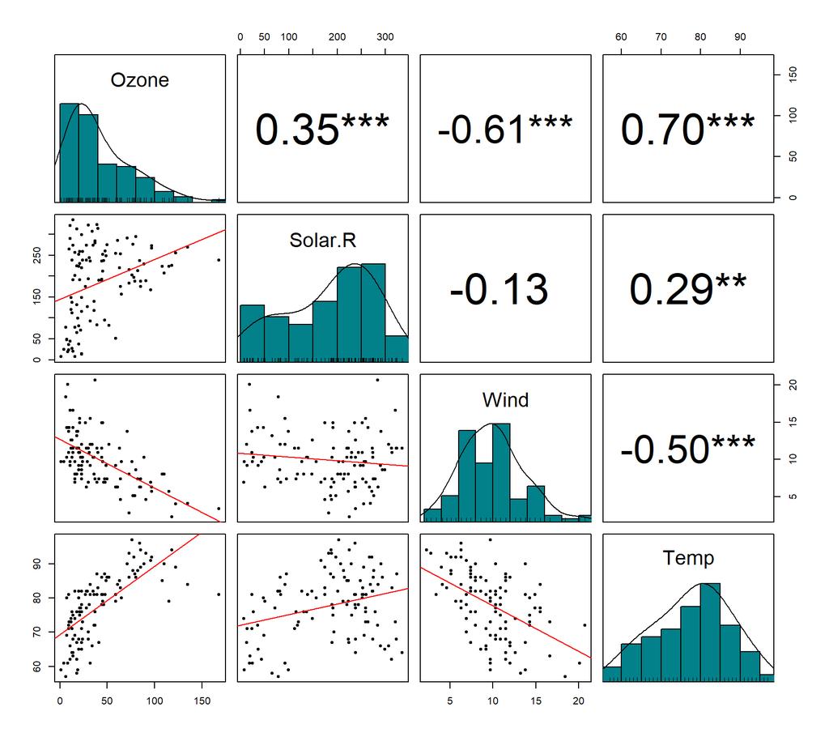

```r
psych::pairs.panels(airquality_complete[, 1:4], ellipses = F,
                    lm = T, smoother = F, stars = T, density = T,
                    scale = F, hist.col="#02818a", show.points=T,
                    pch = 20, cex.cor=1)
```

## Q1.2

**Model 1: fit a linear regression model with the ozone level as an independent variable and the solar radiation as a predictor**

```r
m1 <- lm(Ozone ~ Solar.R, data = airquality_complete)
summary(m1)
```

```
##
## Call:
## lm(formula = Ozone ~ Solar.R, data = airquality_complete)
##
## Residuals:
##     Min      1Q  Median      3Q     Max
## -48.292 -21.361  -8.864  16.373 119.136
##
## Coefficients:
##             Estimate Std. Error t value Pr(>|t|)
## (Intercept) 18.59873    6.74790   2.756 0.006856 **
## Solar.R      0.12717    0.03278   3.880 0.000179 ***
## ---
## Signif. codes:  0 '***' 0.001 '**' 0.01 '*' 0.05 '.' 0.1 ' ' 1
##
## Residual standard error: 31.33 on 109 degrees of freedom
## Multiple R-squared:  0.1213, Adjusted R-squared:  0.1133
## F-statistic: 15.05 on 1 and 109 DF,  p-value: 0.0001793
```

## Q1.3

**Model 2: add the covariate wind speed to the model and use the likelihood ratio test to test of this covariate is needed**

Add the covariate wind speed to the model

```r
m2 <- update(m1, .~. + Wind)
summary(m2)
```

```
##
## Call:
## lm(formula = Ozone ~ Solar.R + Wind, data = airquality_complete)
##
## Residuals:
##     Min      1Q  Median      3Q     Max
## -45.651 -18.164  -5.959  18.514  85.237
##
## Coefficients:
##             Estimate Std. Error t value Pr(>|t|)
## (Intercept) 77.24604    9.06751   8.519 1.05e-13 ***
## Solar.R      0.10035    0.02628   3.819 0.000224 ***
## Wind        -5.40180    0.67324  -8.024 1.34e-12 ***
## ---
## Signif. codes:  0 '***' 0.001 '**' 0.01 '*' 0.05 '.' 0.1 ' ' 1
##
## Residual standard error: 24.92 on 108 degrees of freedom
## Multiple R-squared:  0.4495, Adjusted R-squared:  0.4393
## F-statistic: 44.09 on 2 and 108 DF,  p-value: 1.003e-14
```

Use the likelihood ratio test to test of this covariate is needed

```r
# Calculate chi-squared statistics, which is -2 loglikelihood difference
chi_stat <- -2 *(logLik(m1) - logLik(m2))[1]
# Calculate p value
pchisq(chi_stat, df = 1, lower.tail = F)
```

```
## [1] 5.843457e-13
```

```r
# Or simply use lrtest function from lmtest package
lmtest::lrtest(m1, m2)
```

```
## Likelihood ratio test
##
## Model 1: Ozone ~ Solar.R
## Model 2: Ozone ~ Solar.R + Wind
##   #Df  LogLik Df  Chisq Pr(>Chisq)
## 1   3 -538.86
## 2   4 -512.91  1 51.899  5.843e-13 ***
## ---
## Signif. codes:  0 '***' 0.001 '**' 0.01 '*' 0.05 '.' 0.1 ' ' 1
```

But it makes more sense if we compare the partial F test in this case

```r
anova(m1, m2)
```

```
## Analysis of Variance Table
##
## Model 1: Ozone ~ Solar.R
## Model 2: Ozone ~ Solar.R + Wind
##   Res.Df    RSS Df Sum of Sq      F    Pr(>F)
## 1    109 107022
## 2    108  67053  1     39969 64.378 1.338e-12 ***
## ---
## Signif. codes:  0 '***' 0.001 '**' 0.01 '*' 0.05 '.' 0.1 ' ' 1
```

$\rightarrow$ Include `wind speed` in the model helps to predict the `ozone level` better

## Q1.4

**Plot the observed ozone level versus the predicated values of model 1 and model 2 and calculate the correlation between the observed and the predicted data for the two models**

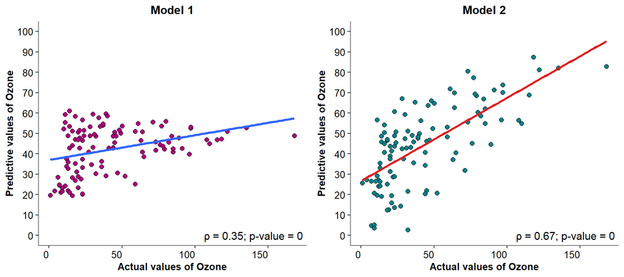

```r
mytheme1 <- function(...) {
  theme(
    panel.grid.major = element_blank(),
    panel.grid.minor = element_blank(),
    panel.border = element_blank(),
    axis.line = element_line(size = 0.3),
    axis.text = element_text(size = 10, color = "black", hjust=1),
    axis.title = element_text(face = "bold", size = 10, color = "black"),
    plot.title = element_text(face = "bold", size = 12, color = "black", hjust = 0.5),
    legend.position = "top"
    )
}

df_ozone_pred <- tibble(Ozone = airquality_complete$Ozone,
                            Ozone_pred_m1 = fitted(m1),
                            Ozone_pred_m2 = fitted(m2))


m1_corr <- cor.test(df_ozone_pred[[1]], df_ozone_pred[[2]])
m2_corr <- cor.test(df_ozone_pred[[1]], df_ozone_pred[[3]])

df_ozone_pred %>%
  ggplot(aes(x = Ozone, y = Ozone_pred_m1)) +
  geom_point(size = 2, shape = 21, fill = "#ae017e") +
  geom_smooth(method = "lm", se = F, size = 1.2) +
  scale_y_continuous(breaks = seq(0, 100, by = 10), limits = c(0, 100)) +
  annotate("text", x = 140, y = 0,
           label = paste0("\u03c1 = ", round(m1_corr$estimate[[1]], 2),
           "; p-value = ", round(m1_corr$p.value[[1]], 3)), size = 4) +
  theme_bw() +
  mytheme1() +
  labs(
    title = "Model 1",
    x = "Actual values of Ozone",
    y = "Predictive values of Ozone"
  ) ->> F1

df_ozone_pred %>%
  ggplot(aes(x = Ozone, y = Ozone_pred_m2)) +
  geom_point(size = 2, shape = 21, fill = "#02818a") +
  geom_smooth(method = "lm", se = F, size = 1.2, color = "#e31a1c") +
  scale_y_continuous(breaks = seq(0, 100, by = 10), limits = c(0, 100)) +
  annotate("text", x = 140, y = 0,
           label = paste0("\u03c1 = ", round(m2_corr$estimate[[1]], 2),
           "; p-value = ", round(m2_corr$p.value[[1]], 3)), size = 4) +
  theme_bw() +
  mytheme1() +
  labs(
    title = "Model 2",
    x = "Actual values of Ozone",
    y = "Predictive values of Ozone"
  ) ->> F2

gridExtra::grid.arrange(F1, F2, ncol = 2)
```

## Q1.5

**Model 3: add the covariate temperature to the model. Use the likelihood ratio test to test if the extra covariate is needed and print the estimated model parameters**

```r
m3 <- update(m2, .~. + Temp)
summary(m3)
```

```
##
## Call:
## lm(formula = Ozone ~ Solar.R + Wind + Temp, data = airquality_complete)
##
## Residuals:
##     Min      1Q  Median      3Q     Max
## -40.485 -14.219  -3.551  10.097  95.619
##
## Coefficients:
##              Estimate Std. Error t value Pr(>|t|)
## (Intercept) -64.34208   23.05472  -2.791  0.00623 **
## Solar.R       0.05982    0.02319   2.580  0.01124 *
## Wind         -3.33359    0.65441  -5.094 1.52e-06 ***
## Temp          1.65209    0.25353   6.516 2.42e-09 ***
## ---
## Signif. codes:  0 '***' 0.001 '**' 0.01 '*' 0.05 '.' 0.1 ' ' 1
##
## Residual standard error: 21.18 on 107 degrees of freedom
## Multiple R-squared:  0.6059, Adjusted R-squared:  0.5948
## F-statistic: 54.83 on 3 and 107 DF,  p-value: < 2.2e-16
```

Likelihood ratio test comparing model 3 and model 2

```r
lmtest::lrtest(m3, m2)
```

```
## Likelihood ratio test
##
## Model 1: Ozone ~ Solar.R + Wind + Temp
## Model 2: Ozone ~ Solar.R + Wind
##   #Df  LogLik Df  Chisq Pr(>Chisq)
## 1   5 -494.36
## 2   4 -512.91 -1 37.098  1.123e-09 ***
## ---
## Signif. codes:  0 '***' 0.001 '**' 0.01 '*' 0.05 '.' 0.1 ' ' 1
```

Partial F test comparing model 3 and model 2

```r
anova(m3, m2)
```

```
## Analysis of Variance Table
##
## Model 1: Ozone ~ Solar.R + Wind + Temp
## Model 2: Ozone ~ Solar.R + Wind
##   Res.Df   RSS Df Sum of Sq      F    Pr(>F)
## 1    107 48003
## 2    108 67053 -1    -19050 42.463 2.424e-09 ***
## ---
## Signif. codes:  0 '***' 0.001 '**' 0.01 '*' 0.05 '.' 0.1 ' ' 1
```

$\rightarrow$ Include `temperature` help to predict the `ozone level` better

## Q1.6

**For model 3, produce the diagnostic plots below.**

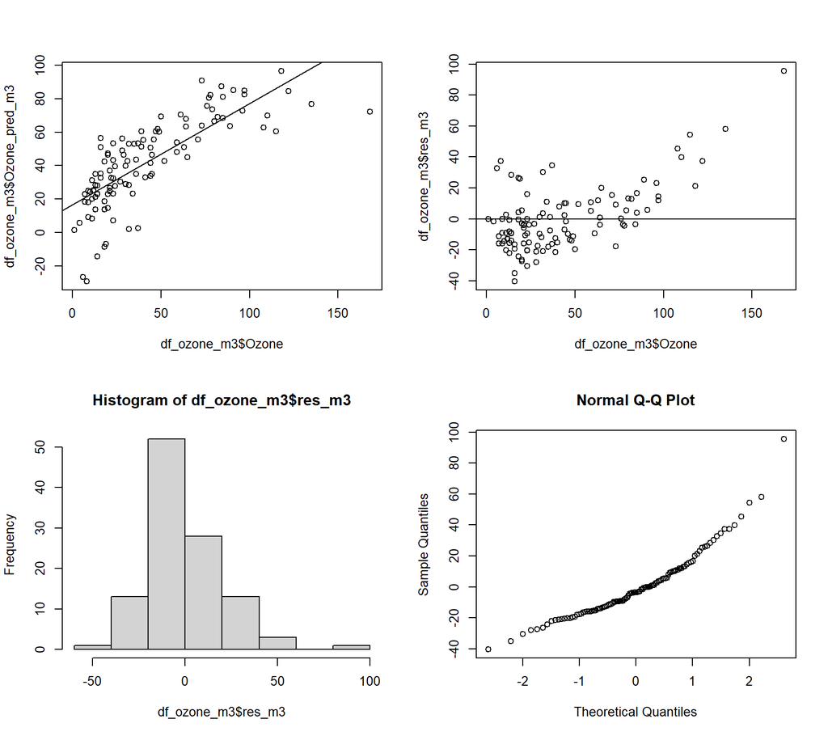

```r
df_ozone_m3 <- tibble(Ozone = airquality_complete$Ozone,
                            Ozone_pred_m3 = fitted(m3),
                            res_m3 = residuals(m3))

par(mfrow = c(2, 2))
plot(df_ozone_m3$Ozone, df_ozone_m3$Ozone_pred_m3)
abline(lm(Ozone_pred_m3 ~ Ozone, data = df_ozone_m3))

plot(df_ozone_m3$Ozone, df_ozone_m3$res_m3)
abline(h = 0)

hist(df_ozone_m3$res_m3)

qqnorm(df_ozone_m3$res_m3)
```

# Question 2

**In this question we focus on the `mtcars` data which available as data frame in R. Use `help(mtcars)` to get information about the data. The dependent variable is the mile per galon (mpg)**

```r
data("mtcars")
head(mtcars)
```

```
##                    mpg cyl disp  hp drat    wt  qsec vs am gear carb
## Mazda RX4         21.0   6  160 110 3.90 2.620 16.46  0  1    4    4
## Mazda RX4 Wag     21.0   6  160 110 3.90 2.875 17.02  0  1    4    4
## Datsun 710        22.8   4  108  93 3.85 2.320 18.61  1  1    4    1
## Hornet 4 Drive    21.4   6  258 110 3.08 3.215 19.44  1  0    3    1
## Hornet Sportabout 18.7   8  360 175 3.15 3.440 17.02  0  0    3    2
## Valiant           18.1   6  225 105 2.76 3.460 20.22  1  0    3    1
```

## Q2.1

**Fit a linear regression model in which the predictor is the cars’ weight (wt), print the output.**

```r
m2_1 <- lm(mpg ~ wt, data = mtcars)
summary(m2_1)
```

```
##
## Call:
## lm(formula = mpg ~ wt, data = mtcars)
##
## Residuals:
##     Min      1Q  Median      3Q     Max
## -4.5432 -2.3647 -0.1252  1.4096  6.8727
##
## Coefficients:
##             Estimate Std. Error t value Pr(>|t|)
## (Intercept)  37.2851     1.8776  19.858  < 2e-16 ***
## wt           -5.3445     0.5591  -9.559 1.29e-10 ***
## ---
## Signif. codes:  0 '***' 0.001 '**' 0.01 '*' 0.05 '.' 0.1 ' ' 1
##
## Residual standard error: 3.046 on 30 degrees of freedom
## Multiple R-squared:  0.7528, Adjusted R-squared:  0.7446
## F-statistic: 91.38 on 1 and 30 DF,  p-value: 1.294e-10
```

## Q2.2

**Use the R function `update()` to add the *factor* cylinders (cyl) as a covariate to the model, print the output**

```r
m2_2 <- update(m2_1, .~. + as.factor(cyl))
summary(m2_2)
```

```
##
## Call:
## lm(formula = mpg ~ wt + as.factor(cyl), data = mtcars)
##
## Residuals:
##     Min      1Q  Median      3Q     Max
## -4.5890 -1.2357 -0.5159  1.3845  5.7915
##
## Coefficients:
##                 Estimate Std. Error t value Pr(>|t|)
## (Intercept)      33.9908     1.8878  18.006  < 2e-16 ***
## wt               -3.2056     0.7539  -4.252 0.000213 ***
## as.factor(cyl)6  -4.2556     1.3861  -3.070 0.004718 **
## as.factor(cyl)8  -6.0709     1.6523  -3.674 0.000999 ***
## ---
## Signif. codes:  0 '***' 0.001 '**' 0.01 '*' 0.05 '.' 0.1 ' ' 1
##
## Residual standard error: 2.557 on 28 degrees of freedom
## Multiple R-squared:  0.8374, Adjusted R-squared:   0.82
## F-statistic: 48.08 on 3 and 28 DF,  p-value: 3.594e-11
```

# Question 3

**In this question we focus on the `mtcars` data.**

## Q3.1

**Fit a one way ANOVA model in which the independent variable is mile per galon (mpg) and the factor is the number of cylinders (cyl), use the R function `lm()`**

```r
lm3_1 <- lm(mpg ~ as.factor(cyl), data = mtcars)
summary(lm3_1)
```

```
##
## Call:
## lm(formula = mpg ~ as.factor(cyl), data = mtcars)
##
## Residuals:
##     Min      1Q  Median      3Q     Max
## -5.2636 -1.8357  0.0286  1.3893  7.2364
##
## Coefficients:
##                 Estimate Std. Error t value Pr(>|t|)
## (Intercept)      26.6636     0.9718  27.437  < 2e-16 ***
## as.factor(cyl)6  -6.9208     1.5583  -4.441 0.000119 ***
## as.factor(cyl)8 -11.5636     1.2986  -8.905 8.57e-10 ***
## ---
## Signif. codes:  0 '***' 0.001 '**' 0.01 '*' 0.05 '.' 0.1 ' ' 1
##
## Residual standard error: 3.223 on 29 degrees of freedom
## Multiple R-squared:  0.7325, Adjusted R-squared:  0.714
## F-statistic:  39.7 on 2 and 29 DF,  p-value: 4.979e-09
```

## Q3.2

**Fit a one way ANOVA model in which the independent variable is mile per galon and the factor is the number of cylinders, use the R function `aov()`. 3.Print the output of both models. the Residual standard error reported in the `lm()` output is equal to 3.223 where can you find this number in the output obtained from the `aov()` function?**

```r
anova3_2 <- aov(mpg ~ as.factor(cyl), data = mtcars)
summary(anova3_2)
```

```
##                Df Sum Sq Mean Sq F value   Pr(>F)
## as.factor(cyl)  2  824.8   412.4    39.7 4.98e-09 ***
## Residuals      29  301.3    10.4
## ---
## Signif. codes:  0 '***' 0.001 '**' 0.01 '*' 0.05 '.' 0.1 ' ' 1
```

Compute residual standard error

```r
sqrt(sum(anova3_2$residuals^2)/anova3_2$df.residual)
```

```
## [1] 3.223099
```

# Question 4

**In this question we focus on the chickwts data which available as data frame in R. Use `help(chickwts)` to get information about the data. The independent variable is the chicken weight (weight) and the factor is the diet group (feed)**

```r
data("chickwts")
head(chickwts)
```

```
##   weight      feed
## 1    179 horsebean
## 2    160 horsebean
## 3    136 horsebean
## 4    227 horsebean
## 5    217 horsebean
## 6    168 horsebean
```

## Q4.1

**Produce the data frame below (which shows the sample mean and variance per diet group).**

```r
chickwts %>%
  group_by(feed) %>%
  summarise(means = mean(weight),
          vars = var(weight)) ->> chick_summary
chick_summary
```

```
## # A tibble: 6 x 3
##   feed      means  vars
## * <fct>     <dbl> <dbl>
## 1 casein     324. 4152.
## 2 horsebean  160. 1492.
## 3 linseed    219. 2729.
## 4 meatmeal   277. 4212.
## 5 soybean    246. 2930.
## 6 sunflower  329. 2385.
```

## Q4.2

**Fit a one way ANOVA model in which the independent variable is weight and the factor is the diet group. Print the output of the model**

```r
anova4_2 <- aov(weight ~ feed, data = chickwts)
summary(anova4_2)
```

```
##             Df Sum Sq Mean Sq F value   Pr(>F)
## feed         5 231129   46226   15.37 5.94e-10 ***
## Residuals   65 195556    3009
## ---
## Signif. codes:  0 '***' 0.001 '**' 0.01 '*' 0.05 '.' 0.1 ' ' 1
```

## Q4.3

**Produce all the graphical displays below**

### Violin plot

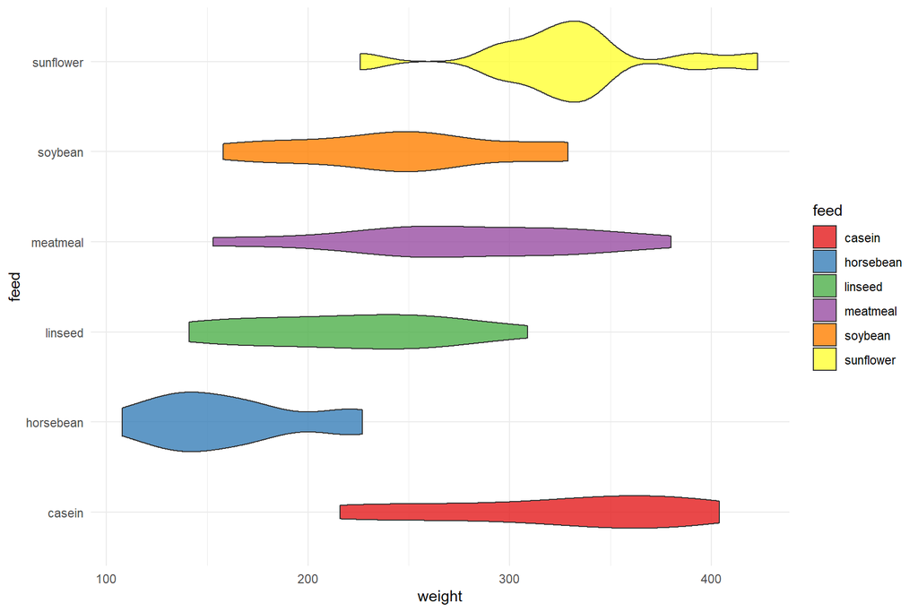

```r
chickwts %>%
  ggplot(aes(x = feed, y = weight, fill = feed)) +
  geom_violin(alpha = 0.8) +
  scale_fill_brewer(palette = "Set1") +
  coord_flip() +
  theme_minimal()
```

### Violin plot with points

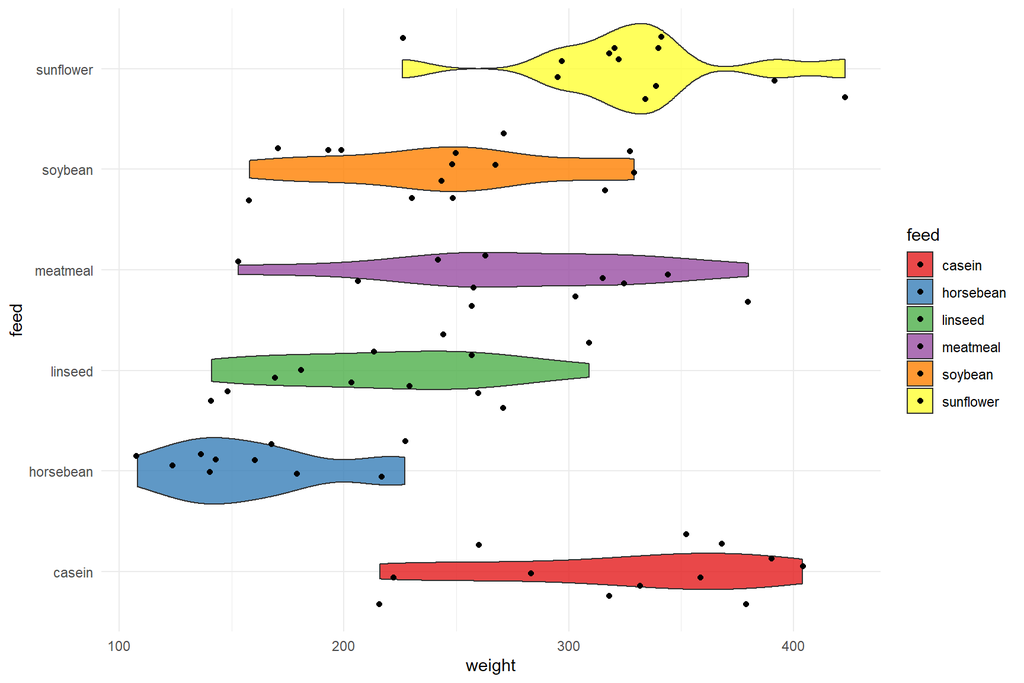

```r
chickwts %>%
  ggplot(aes(x = feed, y = weight, fill = feed)) +
  geom_violin(alpha = 0.8) +
  geom_jitter() +
  scale_fill_brewer(palette = "Set1") +
  coord_flip() +
  theme_minimal()
```

### Point only

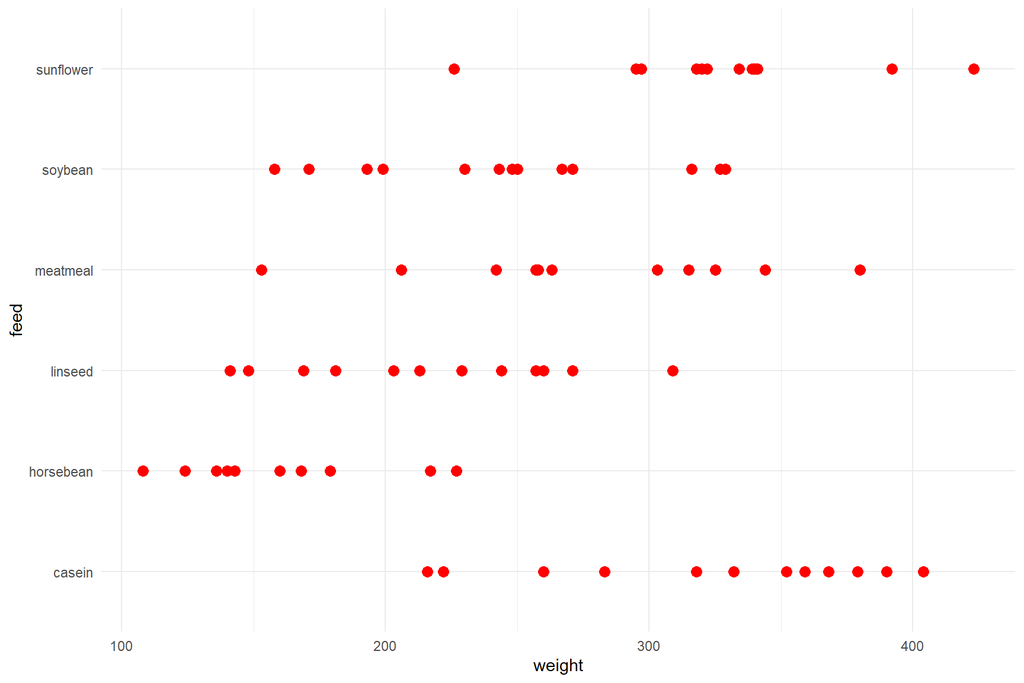

```r
chickwts %>%
  ggplot(aes(x = feed, y = weight)) +
  geom_point(size = 3, color = "red") +
  coord_flip() +
  theme_minimal()
```

### Box plot

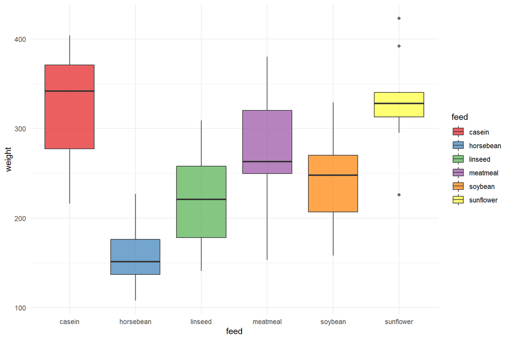

```r
chickwts %>%
  ggplot(aes(x = feed, y = weight, fill = feed)) +
  geom_boxplot(alpha = 0.7) +
  scale_fill_brewer(palette = "Set1") +
  theme_minimal()
```

### Density plot

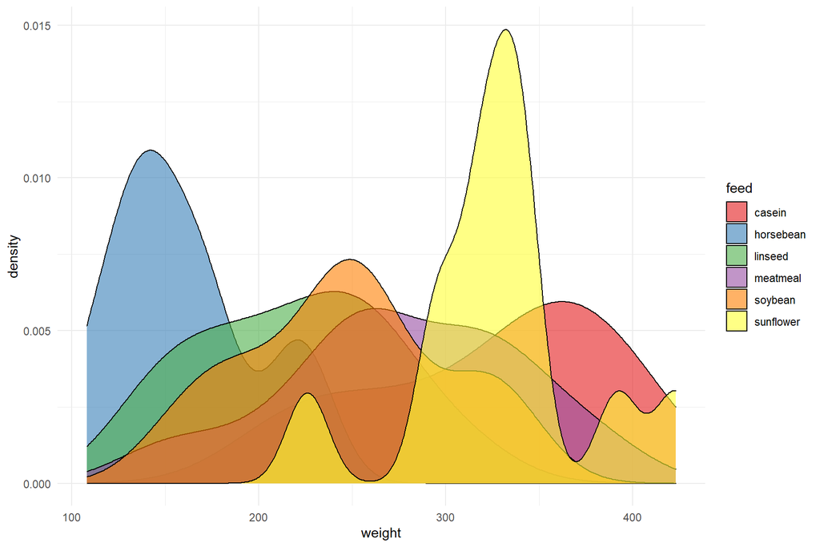

```r
chickwts %>%
  ggplot(aes(x = weight, fill = feed)) +
  geom_density(alpha = 0.6) +
  scale_fill_brewer(palette = "Set1") +
  theme_minimal()
```

### Density plot with facet

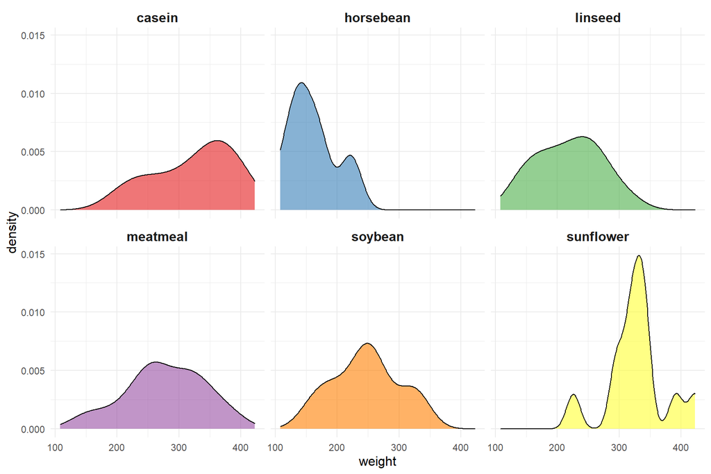

```r
chickwts %>%
  ggplot(aes(x = weight, fill = feed)) +
  geom_density(alpha = 0.6, show.legend = F) +
  facet_wrap(~feed, ncol = 3) +
  scale_fill_brewer(palette = "Set1") +
  theme_minimal() +
  theme(
    axis.title = element_text(size = 12),
    strip.text = element_text(size = 12, face = "bold")
  )
```

### Area plot

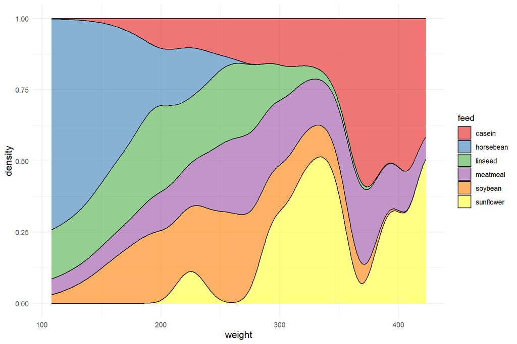

```r
chickwts %>%
  ggplot(aes(x = weight, fill = feed)) +
  geom_area(stat = 'density', position = "fill", alpha = 0.6, color = "black") +
  scale_fill_brewer(palette = "Set1") +
  theme_minimal() +
  theme(
    axis.title = element_text(size = 12),
    strip.text = element_text(size = 12, face = "bold")
  )
```

# Question 5

**In this question we focus on the gapminder dataset. To get the data you need to install the R package gapminder**

```r
library(gapminder)
data("gapminder")
head(gapminder)
```

```
## # A tibble: 6 x 6
##   country     continent  year lifeExp      pop gdpPercap
##   <fct>       <fct>     <int>   <dbl>    <int>     <dbl>
## 1 Afghanistan Asia       1952    28.8  8425333      779.
## 2 Afghanistan Asia       1957    30.3  9240934      821.
## 3 Afghanistan Asia       1962    32.0 10267083      853.
## 4 Afghanistan Asia       1967    34.0 11537966      836.
## 5 Afghanistan Asia       1972    36.1 13079460      740.
## 6 Afghanistan Asia       1977    38.4 14880372      786.
```

## Q5.1

**The first analysis is focus on Afghanistan. Create a new data frame contains only observations from this country and the variables country (`country`), year (`year`),life expectancy (`lifeExp`) and population size (`pop`). Produce the following output**

```r
gapminder %>%
  filter(country == "Afghanistan") %>%
  select(country, year, lifeExp, pop) ->> gapminder_af

gapminder_af
```

```
## # A tibble: 12 x 4
##    country      year lifeExp      pop
##    <fct>       <int>   <dbl>    <int>
##  1 Afghanistan  1952    28.8  8425333
##  2 Afghanistan  1957    30.3  9240934
##  3 Afghanistan  1962    32.0 10267083
##  4 Afghanistan  1967    34.0 11537966
##  5 Afghanistan  1972    36.1 13079460
##  6 Afghanistan  1977    38.4 14880372
##  7 Afghanistan  1982    39.9 12881816
##  8 Afghanistan  1987    40.8 13867957
##  9 Afghanistan  1992    41.7 16317921
## 10 Afghanistan  1997    41.8 22227415
## 11 Afghanistan  2002    42.1 25268405
## 12 Afghanistan  2007    43.8 31889923
```

## Q5.2

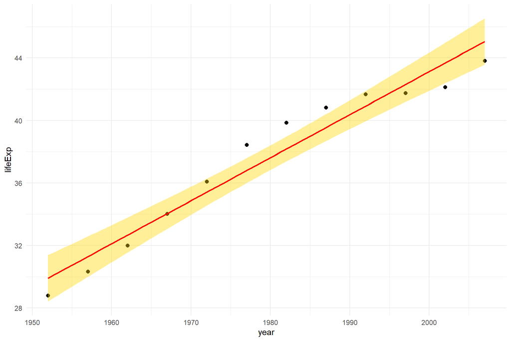

```r
gapminder_af %>%
  ggplot(aes(x = year, y = lifeExp)) +
  geom_point(size = 2) +
  geom_smooth(method = "lm", fill = "gold", color = "red") +
  theme_minimal()
```

## Q5.3

**The figure below was produce in order to investigate the relationship between life expectancy and population size and it evolution over the time. Produce the same figure**

Hint: https://www.r-graph-gallery.com/connected_scatterplot_ggplot2.html

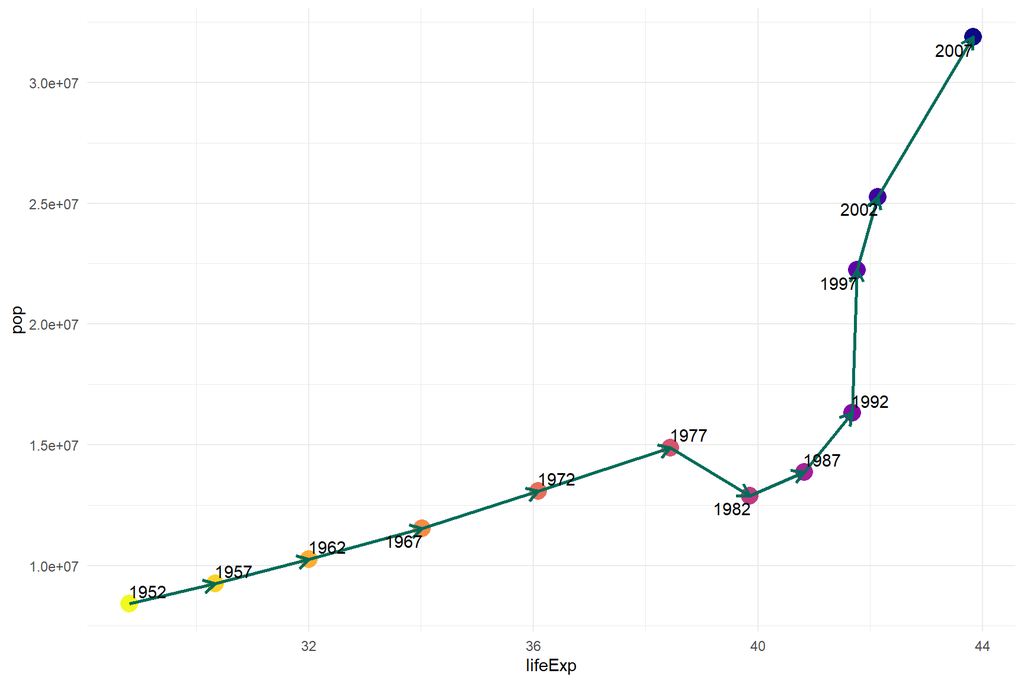

```r
gapminder_af %>%
  ggplot(aes(x = lifeExp, y = pop, label = year)) +
  geom_point(aes(color = year), size = 5, show.legend = F) +
  scale_color_viridis(option = "C", direction = -1) +
  geom_segment(aes(xend = c(tail(lifeExp, n = -1), NA),
                    yend = c(tail(pop, n = -1), NA)),
               arrow = arrow(length = unit(0.3, "cm"), type = "open"),
               size = 1, color = "#016c59") +
  geom_text_repel() +
  theme_minimal()
```

## Q5.4

**In this question we focus on observations (from all countries) from 2007. How many observations are included in the analysis ? The investigators are interested to compare the life expectancy between the continents. Two figures, presented below, are suggested. Produce the two figures. Which one is better to answer the research question?**

Number of observarion

```r
gapminder_2007 <- gapminder %>% filter(year == 2007)

# Number of observarion
nrow(gapminder_2007)
```

```
## [1] 142
```

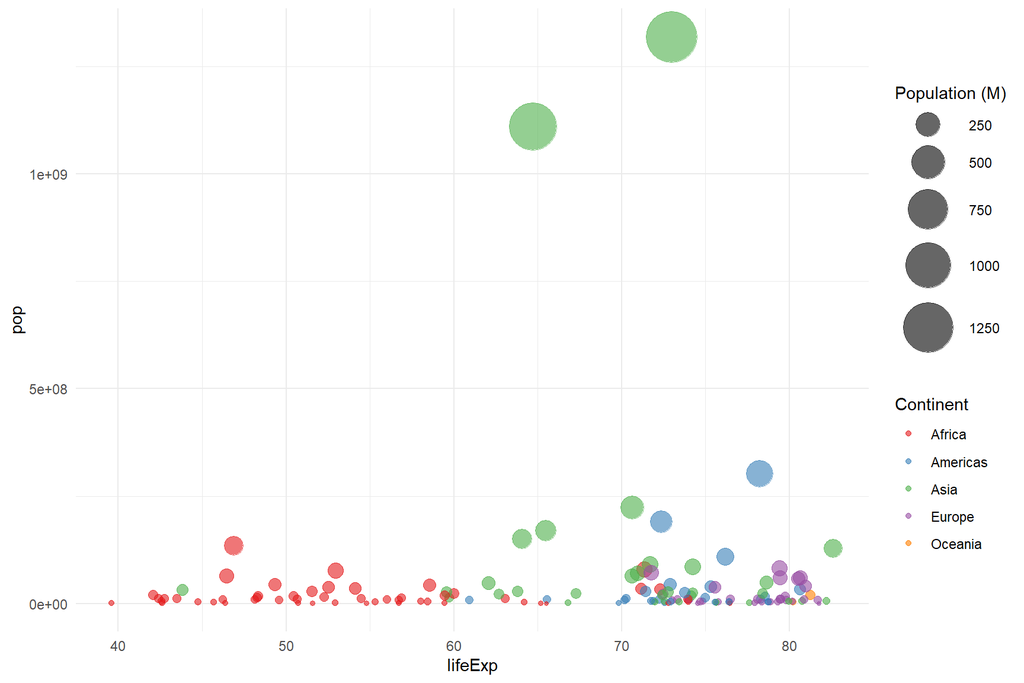

Figure 5.1

```r
gapminder_2007 %>%
  ggplot(aes(x = lifeExp, y = pop)) +
  geom_point(aes(size = pop/10^6, color = continent), alpha = 0.6) +
  scale_size(range = c(1, 15)) +
  scale_color_brewer(palette = "Set1") +
  theme_minimal() +
  labs(
    color = "Continent",
    size = "Population (M)"
  )
```

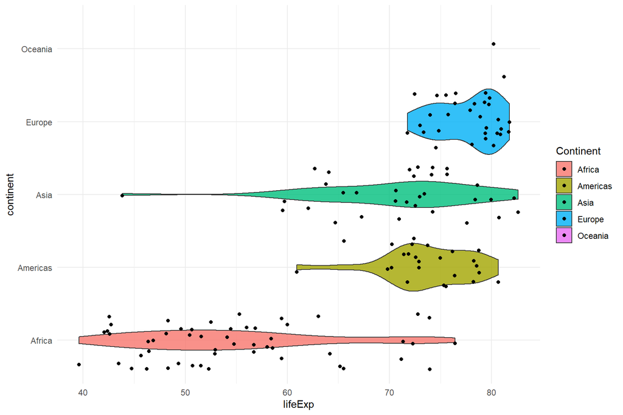

Figure 5.2

```r
gapminder_2007 %>%
  ggplot(aes(x = lifeExp, y = continent, fill = continent)) +
  geom_violin( alpha = 0.8) +
  geom_jitter() +
  scale_color_brewer(palette = "Set1") +
  theme_minimal() +
  labs(
    fill = "Continent"
  )
```

$\rightarrow$ To compare the life expectancy between the continents, Figure 5.2 is more appropriate than Figure 5.1